# 📊 Gym Inflation vs Income: Is Fitness Becoming a Luxury?

```python
import pandas as pd

# Load uploaded files
income_path = "../data/income_data.csv"
gym_costs_path = "../data/gym_costs.csv"

income_df = pd.read_csv(income_path)
gym_df = pd.read_csv(gym_costs_path)

income_df.head(), gym_df.head()
```

```
(  observation_date  MEHOINUSA672N
 0       2000-01-01          70020
 1       2001-01-01          68870
 2       2002-01-01          68310
 3       2003-01-01          68350
 4       2004-01-01          68250,
   Consumer Price Index for All Urban Consumers (CPI-U)  \
 0                                Original Data Value
 1                                                NaN
 2                                         Series Id:
 3                            Not Seasonally Adjusted
 4                                      Series Title:

                                           Unnamed: 1 Unnamed: 2 Unnamed: 3  \
 0                                                NaN        NaN        NaN
```

[output cut: 18 more lines]

```python
import pandas as pd

# Step 1: Dynamically find the header row in gym CPI dataset
for i, row in gym_df.iterrows():
    if 'Year' in row.tolist():
        header_row = i
        break
else:
    raise ValueError("Header row with 'Year' not found.")

# Step 2: Reload the dataset with proper header
clean_gym_df = pd.read_csv(gym_costs_path, skiprows=header_row + 1)

# Step 3: Drop rows where 'Year' is missing or not numeric
clean_gym_df = clean_gym_df[pd.to_numeric(clean_gym_df['Year'], errors='coerce').notnull()]
clean_gym_df['Year'] = clean_gym_df['Year'].astype(int)

# Step 4: Calculate average CPI from monthly columns
monthly_cols = ['Jan', 'Feb', 'Mar', 'Apr', 'May', 'Jun',
                'Jul', 'Aug', 'Sep', 'Oct', 'Nov', 'Dec']

# Ensure all month columns are numeric
clean_gym_df[monthly_cols] = clean_gym_df[monthly_cols].apply(pd.to_numeric, errors='coerce')

# Compute annual average CPI
clean_gym_df['AvgGymCPI'] = clean_gym_df[monthly_cols].mean(axis=1)

# Step 5: Keep only 'Year' and average CPI
gym_cpi_df = clean_gym_df[['Year', 'AvgGymCPI']]

# Step 6: Clean income dataset
income_df['Year'] = pd.to_datetime(income_df['observation_date']).dt.year
income_df = income_df.rename(columns={'MEHOINUSA672N': 'MedianIncome'})
income_df = income_df[['Year', 'MedianIncome']]

# Step 7: Merge CPI and income data
merged_df = pd.merge(gym_cpi_df, income_df, on='Year')

# Step 8: Display results
print("📊 Gym CPI vs Median Income")
display(merged_df)
```

```
📊 Gym CPI vs Median Income
```

|  | Year | AvgGymCPI | MedianIncome |
| --- | --- | --- | --- |
| 0 | 2000 | 108.891667 | 70020 |
| 1 | 2001 | 111.650000 | 68870 |
| 2 | 2002 | 112.941667 | 68310 |
| 3 | 2003 | 116.108333 | 68350 |
| 4 | 2004 | 116.675000 | 68250 |
| 5 | 2005 | 117.433333 | 69310 |
| 6 | 2006 | 121.850000 | 70080 |
| 7 | 2007 | 123.703167 | 71210 |
| 8 | 2008 | 125.826250 | 68780 |
| 9 | 2009 | 125.667500 | 68340 |
| 10 | 2010 | 123.465667 | 66730 |
| 11 | 2011 | 122.066250 | 65750 |
| 12 | 2012 | 125.493583 | 65740 |
| 13 | 2013 | 127.481833 | 68220 |
| 14 | 2014 | 129.331000 | 67360 |
| 15 | 2015 | 130.142083 | 71000 |
| 16 | 2016 | 132.198750 | 73520 |
| 17 | 2017 | 135.314667 | 74810 |
| 18 | 2018 | 139.162000 | 75790 |
| 19 | 2019 | 142.867083 | 81210 |
| 20 | 2020 | 145.032917 | 79560 |
| 21 | 2021 | 146.090083 | 79260 |
| 22 | 2022 | 151.455083 | 77540 |
| 23 | 2023 | 157.631500 | 80610 |

```python
# Normalize both to 2000 = 100
base_year = 2000
merged_df['GymCPI_Index'] = merged_df['AvgGymCPI'] / merged_df.loc[merged_df['Year'] == base_year, 'AvgGymCPI'].values[0] * 100
merged_df['Income_Index'] = merged_df['MedianIncome'] / merged_df.loc[merged_df['Year'] == base_year, 'MedianIncome'].values[0] * 100
```

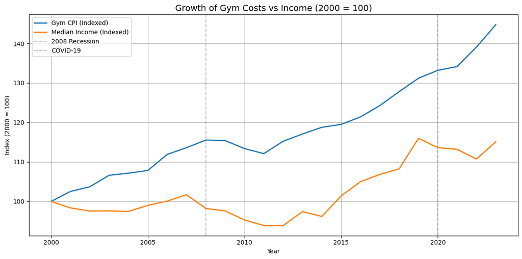

```python
import matplotlib.pyplot as plt

plt.figure(figsize=(12,6))
plt.plot(merged_df['Year'], merged_df['GymCPI_Index'], label='Gym CPI (Indexed)', linewidth=2)
plt.plot(merged_df['Year'], merged_df['Income_Index'], label='Median Income (Indexed)', linewidth=2)
plt.axvline(x=2008, color='gray', linestyle='--', alpha=0.5, label='2008 Recession')
plt.axvline(x=2020, color='gray', linestyle='--', alpha=0.5, label='COVID-19')

plt.title('Growth of Gym Costs vs Income (2000 = 100)', fontsize=14)
plt.xlabel('Year')
plt.ylabel('Index (2000 = 100)')
plt.legend()
plt.grid(True)
plt.tight_layout()

# 🔽 Save the plot as a PNG image
plt.savefig('../visuals/gym_vs_income_indexed.png', dpi=300, bbox_inches='tight')

# Show the plot
plt.show()
```

## 📈 Indexed Growth: Gym Costs vs Income (2000 = 100)

We normalized both gym membership CPI and median income to a base year (2000 = 100) to compare their growth rates fairly.

🧠 **Insight**:

- Gym membership costs have outpaced median income significantly since 2008.
- This trend became more exaggerated post-2020, likely driven by rising demand for premium gyms, personal training, and home fitness equipment during and after COVID lockdowns.
- The income growth, in contrast, has been relatively flat when adjusted for inflation — shrinking accessibility for many.

🧩 This suggests that **fitness is slowly becoming a luxury**, not a basic health utility.

```python
merged_df['Gym_to_Income_Ratio'] = merged_df['AvgGymCPI'] / merged_df['MedianIncome']
```

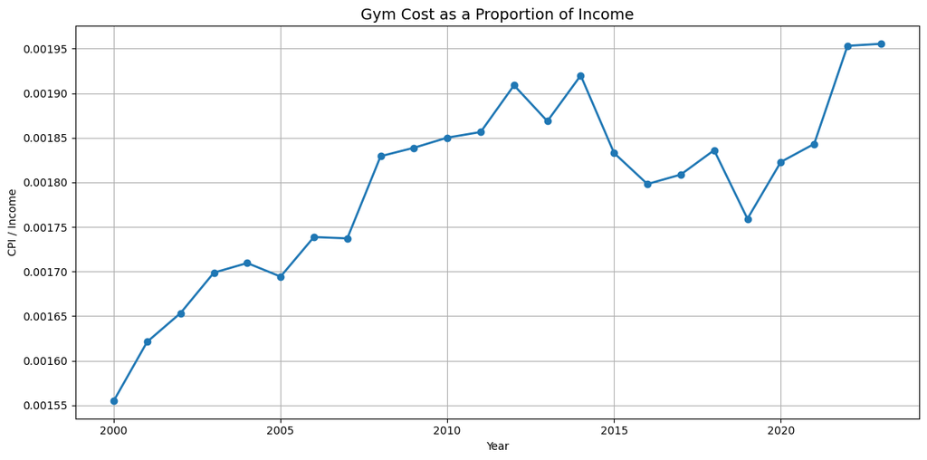

```python
plt.figure(figsize=(12,6))
plt.plot(merged_df['Year'], merged_df['Gym_to_Income_Ratio'], marker='o', linewidth=2)
plt.title('Gym Cost as a Proportion of Income', fontsize=14)
plt.xlabel('Year')
plt.ylabel('CPI / Income')
plt.grid(True)
plt.tight_layout()

# 🔽 Save the plot as a PNG image
plt.savefig('../visuals/gym_income_ratio.png', dpi=300, bbox_inches='tight')

# Show the plot
plt.show()
```

## 💰 Gym Affordability Over Time

This plot shows the ratio of Gym CPI to Median Income, which acts as a proxy for affordability.

⚠️ **Interpretation**: This reinforces the idea that the modern gym industry is evolving toward **aesthetics-driven services (HIIT studios, physique coaching, luxury amenities)** which can price out average users focused on health.

## 🧭 What’s Next?

Now that we’ve established the growing financial barrier to fitness, we’ll explore:

- Has public interest shifted from health to “looking good”?
- Are people chasing six-packs more than longevity?

👉 We’ll answer this using Google Trends data over the last 20 years.